##### 140.711 Advanced Data Science Project

### 0 Preliminary

## 0.0 Set up

Require libraries and set up Twitter API.

```r
install.packages("twitteR",repos = "http://cran.us.r-project.org")
install.packages("RCurl",repos = "http://cran.us.r-project.org")
install.packages("stringr",repos = "http://cran.us.r-project.org")
install.packages("tm",repos = "http://cran.us.r-project.org")
```

```r
install.packages("wordcloud",repos = "http://cran.us.r-project.org")
install.packages("dplyr",repos = "http://cran.us.r-project.org")
install.packages("ggplot2",repos = "http://cran.us.r-project.org")
install.packages("knitr",repos = "http://cran.us.r-project.org")
install.packages("SnowballC",repos = "http://cran.us.r-project.org")
install.packages("glmnet",repos = "http://cran.us.r-project.org")
install.packages("tree",repos = "http://cran.us.r-project.org")
install.packages("randomForest",repos = "http://cran.us.r-project.org")
install.packages("./Rpackages/Rstem_0.4-1.tar.gz",repos = NULL, type = "source")
install.packages("./Rpackages/sentiment_0.1.tar.gz", repos = NULL, type = "source")

library(twitteR)
library(RCurl)
library(stringr)
library(tm)
library(wordcloud)
library(dplyr)
library(sentiment)
library(ggplot2)
library(knitr)
library(SnowballC)
#output setup
opts_chunk$set(cache=TRUE)
#API setup
consumer_key <- 'E4k6sWu82oC7z9S13LhV424Iy'
consumer_secret <- 'dOT6Bzykf5WMPf8krcUZCfqCRZFYCbpKbJ7LtPUTZpyXXjhtGN'
access_token <- '3838169536-ICB596gXntmZBc9jxzWH8brtRBsuHfORX5Ev4z4'
access_secret <- 'OpFZh6flRX5pMT23BzMyKyc32QLdcXqltHo1Q3pSuyLoC'
setup_twitter_oauth(consumer_key,consumer_secret,access_token,access_secret)
```

```
## [1] "Using direct authentication"
```

2 functions to do text cleaning and count the number of words.

```r
MyClean <- function(status){#character list
        status.clean <- gsub("(f|ht)tp(s?)://(.*?)([ ]|$)", "", status) #remove url
        status.clean <- gsub("&amp;", " ", status.clean)
        status.clean <- gsub("RT ", "", status.clean)
        status.clean <- gsub("[[:punct:]]","",status.clean)
        status.clean <- gsub("\n","",status.clean)
        status.clean <-iconv(status.clean,"ASCII", "UTF-8", sub="") #clean emoji
        status.clean
}

MyCount <- function(status.clean,word){#character list,character,search count of word in status.clean
        search.result <- gregexpr(word,status.clean) #return a list of matched starting positions
        search.result <- sapply(search.result, function(x) x!=-1)
        search.result <- sapply(search.result, sum)
        search.result
}
```

## 0.1 Get Potential trolls/fans

Use “mybadwords” dictionary to search for potential troll tweets and fan tweets. Each line is a tweet for a person. The first word is the username and the rest is the content of the tweet. Save the file as “mean.txt” and “love.txt” for trolls and fans seperately.

```r
#not run this chuck
kCelebrity <- "taylorswift13"
kDictionary.1 <- as.vector(readLines("mybadwords"))

#search for potential mean tweets
for (i in 1:length(kDictionary.1))
{
        kWord <- paste(kCelebrity,"+",kDictionary.1[i])
        status <- searchTwitter(kWord,lang="en",n=300,resultType = "recent")
        sapply(status, function(x) write.table(paste(x$screenName,x$text,sep=' '),"./data/mean.txt",row.names = FALSE,col.names = FALSE,append = TRUE))
}
#search for potential fan tweets
status <- strip_retweets(searchTwitter("taylorswift13 + love",lang="en",n=3000,resultType = "recent"))
sapply(status, function(x) write.table(paste(x$screenName,x$text,sep=' '),"./data/love.txt",row.names = FALSE,col.names = FALSE,append = TRUE))
```

## 0.2 Manually select true troll/fan tweets and get true troll/fan usernames

Manually delete tweets that are not trolls in “mean.txt” file and tweets that are not fans in “love.txt” file. Read in the modified file and get the first word as usernames for true trolls and fans. Save the usernames for trolls as “usernames_mean” and “usernames_fan” for fans.

```r
mean <- gsub("\"","",readLines("./data/mean.txt"))
mean.users <- unique(word(mean,1))
love <- gsub("\"","",readLines("./data/love.txt"))
fan.users <- unique(word(love,1))
write.table(mean.users,"./data/usernames_mean.txt",sep = "\n",row.names = FALSE,col.names = FALSE,append = T)
write.table(fan.users,"./data/usernames_fan.txt",sep = "\n",row.names = FALSE,col.names = FALSE,append = T)
```

## 0.3 Search for tweets for each of the troll/fan.

Search for most recent n=200 tweets for each identified troll/fan. There is rate limit for this search so wait for 15 minutes if reaching the rate limit. Also some accounts are private, so I manually delete them in the “usernames_mean.txt” and “usernames_fan.txt”. For each tweet returned, use MyClean() function to get a clean version of the text(i.e. remove URL and hex coded emoji). Save the file as “status_mean_all.txt” and “status_mean_clean.txt” for raw and clean version for trolls. Similarly for fans. In each file, each username is followed by tweets of that user, with each tweet a seperate line.

```r
#not run
for (i in i:n.mean){
                name <- mean.users[i]
                status.all <- userTimeline(name,n=200)
                status.all.text <- sapply(status.all,function(x) x$getText())
                status.all.text.clean <- MyClean(status.all.text)
                write.table(name,"./data/status_mean_all.txt",row.names = FALSE, col.names = FALSE,append=TRUE)
                write.table(status.all.text,"./data/status_mean_all.txt",col.names = FALSE,append=TRUE)
                write.table(name,"./data/status_mean_clean.txt",row.names = FALSE, col.names = FALSE,append=TRUE)
                write.table(status.all.text.clean,"./data/status_mean_clean.txt",col.names = FALSE, append=TRUE)
}

for (j in j:n.fan){
        name <- fan.users[j]
        status.all <- userTimeline(name,n=200)
        status.all.text <- sapply(status.all,function(x) x$getText())
        status.all.text.clean <- MyClean(status.all.text)
        write.table(name,"./data/status_fan_all.txt",row.names = FALSE, col.names = FALSE,append=TRUE)
        write.table(status.all.text,"./data/status_fan_all.txt",col.names = FALSE,append=TRUE)
        write.table(name,"./data/status_fan_clean.txt",row.names = FALSE, col.names = FALSE,append=TRUE)
        write.table(status.all.text.clean,"./data/status_fan_clean.txt",col.names = FALSE, append=TRUE)
}
```

### 1 Raw Data

We have modified usernames “usernames_mean.txt” for trolls and “usernames_fan.txt” for fans (deleting those private accounts). Also for each of these users, we have returned most recent 200 tweets, “status_mean_clean.txt” for trolls and “status_fan_clean.txt” for fans. Check out these data. There are 290 mean users and 510 fan users. Totally there are 25,915 tweets for mean users and 41,244 tweets for fan users.

```r
#mean user
mean.users <- as.vector(read.table("./data/usernames_mean.txt")[,1])
head(mean.users)
```

```
## [1] "Jenny_o1987"   "jolladoerk"    "JasonGiraldo5" "Marquez249"
## [5] "my66"          "KVelvet"
```

```r
n.mean <- length((mean.users))
n.mean
```

```
## [1] 290
```

```r
#fan user
fan.users <- as.vector(read.table("./data/usernames_fan.txt")[,1])
head(fan.users)
```

```
## [1] "aaronmetran"    "SurfingGaunty"  "CindyCharmel"   "taylorftrubiuh"
## [5] "curlyjenner"    "HollyCrozier"
```

```r
n.fan <- length((fan.users))
n.fan
```

```
## [1] 510
```

```r
#mean tweets
text.mean <- readLines("./data/status_mean_clean.txt")
text.mean <- gsub("\"","",text.mean)
text.mean <- gsub("^[0-9](.*?)[ ]","",text.mean)
head(text.mean)
```

```
## [1] "Jenny_o1987"
## [2] "Turns out #Petewicks has joined a percentage of the male population who are never satisfied with what they have and downgrade! #Meganmcisfit"
## [3] "#Jacquiryland definition of how to be classy!!  Put your arse and tits away love and go do a porno!!!"
## [4] "@SimonCowell is this why you binned #Louiswalsh off to begin with because he doesn't have a clue about TALENT!? The show is a joke #Xfactor"
## [5] "#Louiswalsh you absolute cunt!! No wonder westlife went bust when you drop actual talent for fucking jokes!!! #Xfactorisajoke #Xfactor"
## [6] "'couples that train together stay together' HAHAHAHAHAHA FUCK OFF!!!!"
```

```r
N.mean <- length(text.mean)-n.mean
N.mean
```

```
## [1] 25915
```

```r
#fan tweets
text.fan <- readLines("./data/status_fan_clean.txt")
text.fan <- gsub("\"","",text.fan)
text.fan <- gsub("^[0-9](.*?)[ ]","",text.fan)
head(text.fan)
```

```
## [1] "aaronmetran"
## [2] "legend to be calledcongrats love taylorswift13  "
## [3] "Infairness MyJaps "
## [4] "Ang initListening to onedirections playlist on Spotify"
## [5] "onedirection LouisTomlinson "
## [6] "Im not a fan of them but Im really proud because of their 6 years in the industrywow "
```

```r
N.fan <- length(text.fan)-n.fan
N.fan
```

```
## [1] 41244
```

### 2 EDA

## 2.0 Summary statistics

Reconstruct a list object from the raw data where each element of the list are tweets from each person. I first find the corresponding line of each username and find their corresponding tweets to construct the list. Store the list as “tweet.mean.list” and “tweet.fan.list”. Count number of tweets for each person and plot the distribution of number of tweets for trolls and fans. There are on average 89 tweets for mean users and 81 tweets for fan users. Trolls tend to have more tweets than fans.

```r
#mean list
cut.mean <- sapply(mean.users,function(x) which(text.mean==x))
cut.mean <- sapply(cut.mean, function(x) unlist(x)[1])
cut.mean[n.mean+1] <- length(text.mean)+1
tweet.mean.list <- NULL
for (i in 1:n.mean){
        tweet.mean.list[[i]] <- text.mean[(cut.mean[i]+1):(cut.mean[i+1]-1)]
}
tweet.mean.list[[1]][1:10]
```

```
##  [1] "Turns out #Petewicks has joined a percentage of the male population who are never satisfied with what they have and downgrade! #Meganmcisfit"
##  [2] "#Jacquiryland definition of how to be classy!!  Put your arse and tits away love and go do a porno!!!"
##  [3] "@SimonCowell is this why you binned #Louiswalsh off to begin with because he doesn't have a clue about TALENT!? The show is a joke #Xfactor"
##  [4] "#Louiswalsh you absolute cunt!! No wonder westlife went bust when you drop actual talent for fucking jokes!!! #Xfactorisajoke #Xfactor"
##  [5] "'couples that train together stay together' HAHAHAHAHAHA FUCK OFF!!!!"
##  [6] "#Tysonfury dirty little coke whore  Goodbye belt "
##  [7] "Time to change channels as that shitty #STAGESCHOOL is on.... #Hurryupmic #Cringeschool"
##  [8] "Some people are so fucking desperate and two faced!! #Thehunted I'd rather EARN my money than be a grass...."
##  [9] "Watching #Thehunted can't actually believe that Scottish prick!! #Grass"
## [10] "Joshua v Klitschko!! That should be an interesting fight.... Knew Fury would back out somehow the fanny!! #JoshuaKlitschko"
```

```r
#fan list
cut.fan <- sapply(fan.users,function(x) which(text.fan==x))
cut.fan <- sapply(cut.fan, function(x) unlist(x)[1])
cut.fan[n.fan+1] <- length(text.fan)+1
tweet.fan.list <- NULL
for (i in 1:n.fan){
        tweet.fan.list[[i]] <- text.fan[(cut.fan[i]+1):(cut.fan[i+1]-1)]
}
tweet.fan.list[[1]][1:10]
```

```
##  [1] "legend to be calledcongrats love taylorswift13  "
##  [2] "Infairness MyJaps "
##  [3] "Ang initListening to onedirections playlist on Spotify"
##  [4] "onedirection LouisTomlinson "
##  [5] "Im not a fan of them but Im really proud because of their 6 years in the industrywow "
##  [6] "I would rather have flowers in my hair than diamonds round my neck "
##  [7] "FifthHarmonys 727 album playlist for this day Spotify"
##  [8] "Blown Away joebrooksmusic  "
##  [9] "Cause I dont wanna dance alone"
## [10] "Ara naman tah KimKardashian   "
```

```r
#plot distribution of number of tweets
count.tweet.mean <- sapply(tweet.mean.list, function(x) length(x))
count.tweet.mean.avg <- mean(count.tweet.mean)
count.tweet.mean.avg
```

```
## [1] 89.41724
```

```r
count.tweet.fan <- sapply(tweet.fan.list, function(x) length(x))
count.tweet.fan.avg <- mean(count.tweet.fan)
count.tweet.fan.avg
```

```
## [1] 80.87843
```

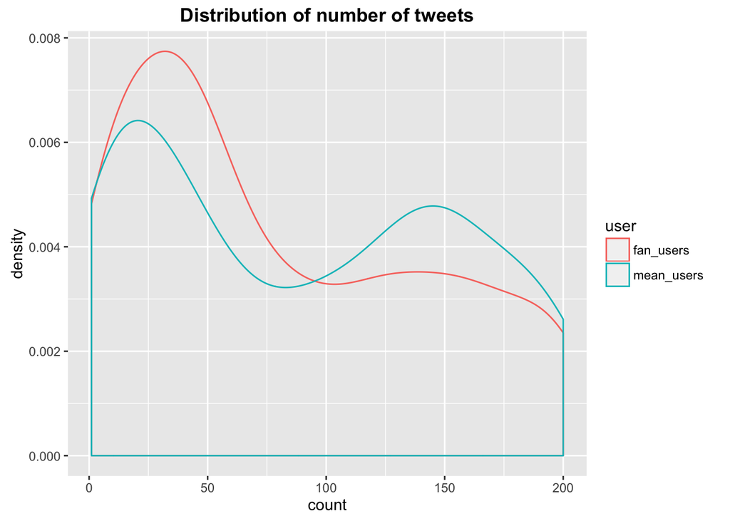

```r
count.tweet <- data.frame(count = c(count.tweet.mean,count.tweet.fan), user = c(rep("mean_users",n.mean),rep("fan_users",n.fan)))

ggplot(count.tweet,aes(x=count,group=user,colour=user)) +
        geom_density() +
        labs(title = "Distribution of number of tweets") +
        theme(plot.title = element_text(lineheight=.8, face="bold"))
```

## 2.1 Wordcloud

Paste all tweets for troll/fan as a single text and construct the term-document matrix to count the number of occurrence of each word. Then manually select words from the top 200 to construct the wordcloud, deleting meaningless words and words of high frequency in both sets.

```r
text.mean.wordcloud <- readLines("./data/status_mean_clean.txt")
text.mean.wordcloud <- gsub("[[:punct:]]","",text.mean.wordcloud)
text.mean.wordcloud <- paste (text.mean.wordcloud, sep = " ", collapse = ' ')
text.mean.wordcloud <- wordStem(text.mean.wordcloud)
text.mean.corpus <- Corpus(VectorSource(text.mean.wordcloud))
text.mean.corpus <- tm_map(text.mean.corpus,content_transformer(tolower))
text.mean.corpus <- tm_map(text.mean.corpus,removeWords,stopwords("en"))
text.mean.corpus <- tm_map(text.mean.corpus,removeWords,"taylorswift13")

matrix.mean <- TermDocumentMatrix(text.mean.corpus)
freq.word <- as.matrix(matrix.mean)
freq.word.order <- freq.word[order(freq.word,decreasing = TRUE),1]
words.mean <- names(freq.word.order[1:200])
select <- c(1,2,3,4,5,6,7,8,9,11,12,13,14,16,18,21,23,29,34,35,44,45,53,59,63,67,73,74,22,20,82,81,93,91,90,27,76,56,85,86,36,38,102,104,106,107,110,112,115,116,117,119,121,122,123,126,127,128,129,133,134,135,136,137,138,140,141,142,143,145,147,150,151,152,153,154,157,159,160,161,162,163,164,166,167,168,170,173,175,176,181,182,184,186,187,188,189,190,195,69,39,97,42,98,193,89,68,109,48,79,57,99,120,62,125,47,24,144,40,114,78,17,149,31)
words.mean <- names(freq.word.order[1:200][-select])
words.mean
```

```
##  [1] "popcrave"        "hillaryclinton"  "fuck"
##  [4] "shit"            "musicnewsfacts"  "even"
##  [7] "lol"             "realdonaldtrump" "never"
## [10] "potus"           "better"          "fucking"
## [13] "bitch"           "omg"             "life"
## [16] "please"          "god"             "ill"
## [19] "man"             "ever"            "stop"
## [22] "best"            "girl"            "happy"
## [25] "hate"            "thank"           "yall"
## [28] "ass"             "well"            "video"
## [31] "trump"           "queen"           "song"
## [34] "music"           "hope"            "bad"
## [37] "follow"          "little"          "dietcoke"
## [40] "fbi"             "black"           "lmao"
## [43] "album"           "great"           "nytimes"
## [46] "old"             "rihanna"         "white"
## [49] "game"            "nbcnews"         "nydailynews"
## [52] "baby"            "liltunechi"      "big"
## [55] "believe"         "damn"            "play"
## [58] "money"           "nas"             "sorry"
## [61] "nice"            "stan"            "beautiful"
## [64] "hell"            "legend"          "noreaga"
## [67] "50cent"          "thegame"         "face"
## [70] "miss"            "theyre"          "birdman5star"
## [73] "die"             "hillary"         "mean"
## [76] "meekmill"
```

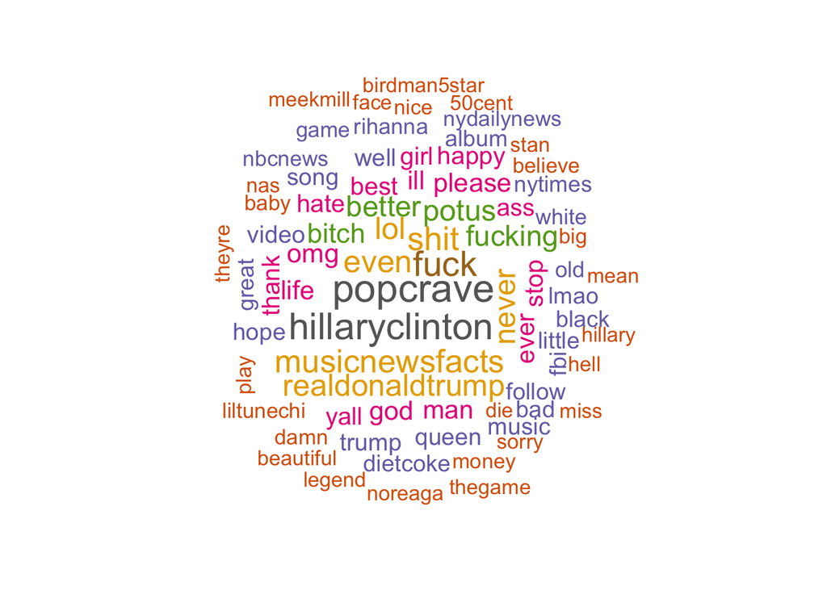

```r
freq.mean <- freq.word.order[1:200][-select]
wordcloud(words.mean,freq.mean,random.order = FALSE,colors=brewer.pal(8, "Dark2"),scale=c(2,0.8))
```

```r
text.fan.wordcloud <- readLines("./data/status_fan_clean.txt")
text.fan.wordcloud <- gsub("[[:punct:]]","",text.fan.wordcloud)
text.fan.wordcloud <- paste (text.fan.wordcloud, sep = " ", collapse = ' ')
text.fan.wordcloud <- wordStem(text.fan.wordcloud)
text.fan.corpus <- Corpus(VectorSource(text.fan.wordcloud))
text.fan.corpus <- tm_map(text.fan.corpus,content_transformer(tolower))
text.fan.corpus <- tm_map(text.fan.corpus,removeWords,stopwords("en"))
text.fan.corpus <- tm_map(text.fan.corpus,removeWords,"taylorswift13")

matrix.fan <- TermDocumentMatrix(text.fan.corpus)
freq.word.fan <- as.matrix(matrix.fan)
freq.word.fan.order <- freq.word.fan[order(freq.word.fan,decreasing = TRUE),1]
words.fan <- names(freq.word.fan.order[1:200])
select.fan <- c(1,2,3,4,5,6,7,8,9,10,11,12,16,17,18,19,20,21,22,23,27,28,30,35,36,39,44,47,50,62,66,68,67,69,70,71,75,76,79,80,84,86,88,89,91,94,97,98,99,100,103,104,105,108,109,112,113,115,117,120,122,123,125,127,128,133,134,135,139,141,146,147,148,151,153,154,155,157,158,160,161,162,166,167,170,172,175,176,177,180,182,184,185,187,188,189,190,191,193,194,197,198,199,200,26,38,119,52,143,25,124,111,145,59,144)
words.fan <- names(freq.word.fan.order[1:200][-select.fan])
words.fan
```

```
##  [1] "happy"            "will"             "please"
##  [4] "always"           "life"             "great"
##  [7] "hope"             "back"             "best"
## [10] "thank"            "taylornation13"   "beautiful"
## [13] "music"            "never"            "follow"
## [16] "lol"              "miss"             "song"
## [19] "ever"             "birthday"         "thanks"
## [22] "right"            "night"            "girl"
## [25] "well"             "even"             "wait"
## [28] "taylorswift"      "ive"              "video"
## [31] "morning"          "amazing"          "quote"
## [34] "world"            "heart"            "ill"
## [37] "hate"             "via"              "better"
## [40] "god"              "guys"             "haha"
## [43] "hahaha"           "live"             "bless"
## [46] "work"             "wish"             "stop"
## [49] "mean"             "cute"             "friends"
## [52] "fun"              "little"           "believe"
## [55] "friend"           "ariastaylorswift" "pretty"
## [58] "bad"              "lang"             "album"
## [61] "praying"          "everyone"         "nice"
## [64] "excited"          "fan"              "protect"
## [67] "help"             "ts6"              "favorite"
## [70] "awesome"          "hard"             "perfect"
## [73] "true"             "wow"              "soon"
## [76] "baby"             "dietcoke"         "queen"
## [79] "long"             "shawnmendes"      "sweet"
## [82] "followers"        "old"              "sad"
## [85] "sorry"
```

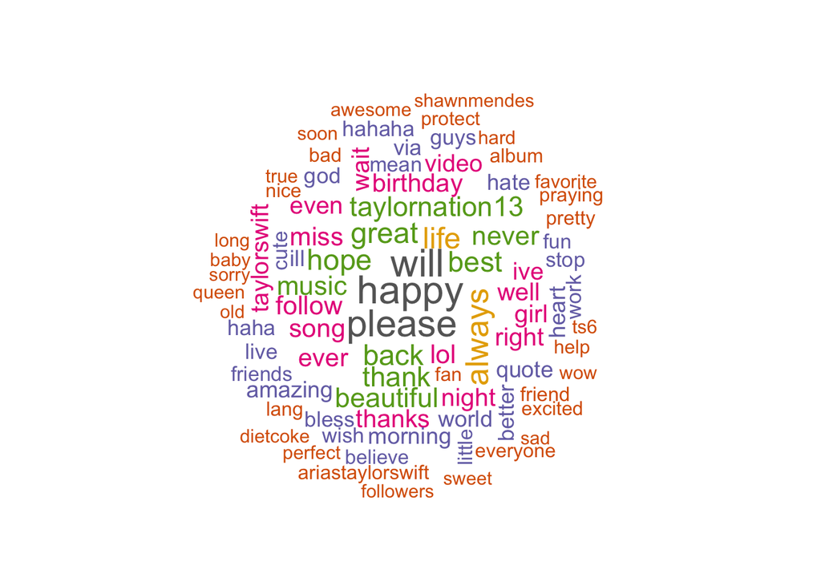

```r
freq.fan <- freq.word.fan.order[1:200][-select.fan]
wordcloud(words.fan,freq.fan,random.order = FALSE,colors=brewer.pal(8, "Dark2"),scale=c(2,0.7))
```

## 2.2 Sentimental Analysis

We conduct 3 levels of sentiment analysis: tweet level, individual level and sentiment percentage level. See detail description in the report. Note that this chuck takes a long time to run. We cache the result in “code_cached”. To re-run the whole analysis, we suggest skip this chuck, by setting “eval = FALSE” of this chuck. It will not influence the results in the rest of the sections.

```r
###tweet level
sentiment.mean <- classify_polarity(unlist(tweet.mean.list), algorithm="bayes")[,4]
sentiment.fan <- classify_polarity(unlist(tweet.fan.list), algorithm="bayes")[,4]
#data frame
sentiment.tweet <- data.frame(emotion = as.factor(rep(c("negative","neutural","positive"),2)), percentage = c(length(which(sentiment.mean=="negative"))/N.mean,length(which(sentiment.mean=="neutral"))/N.mean,length(which(sentiment.mean=="positive"))/N.mean,length(which(sentiment.fan=="negative"))/N.fan,length(which(sentiment.fan=="neutral"))/N.fan,length(which(sentiment.fan=="positive"))/N.fan),class = as.factor(c(rep("mean_user",3),rep("fan_user",3))))
sentiment.tweet
```

```
##    emotion percentage     class
## 1 negative 0.22380861 mean_user
## 2 neutural 0.10970480 mean_user
## 3 positive 0.66710399 mean_user
## 4 negative 0.15653186  fan_user
## 5 neutural 0.08939482  fan_user
## 6 positive 0.75417030  fan_user
```

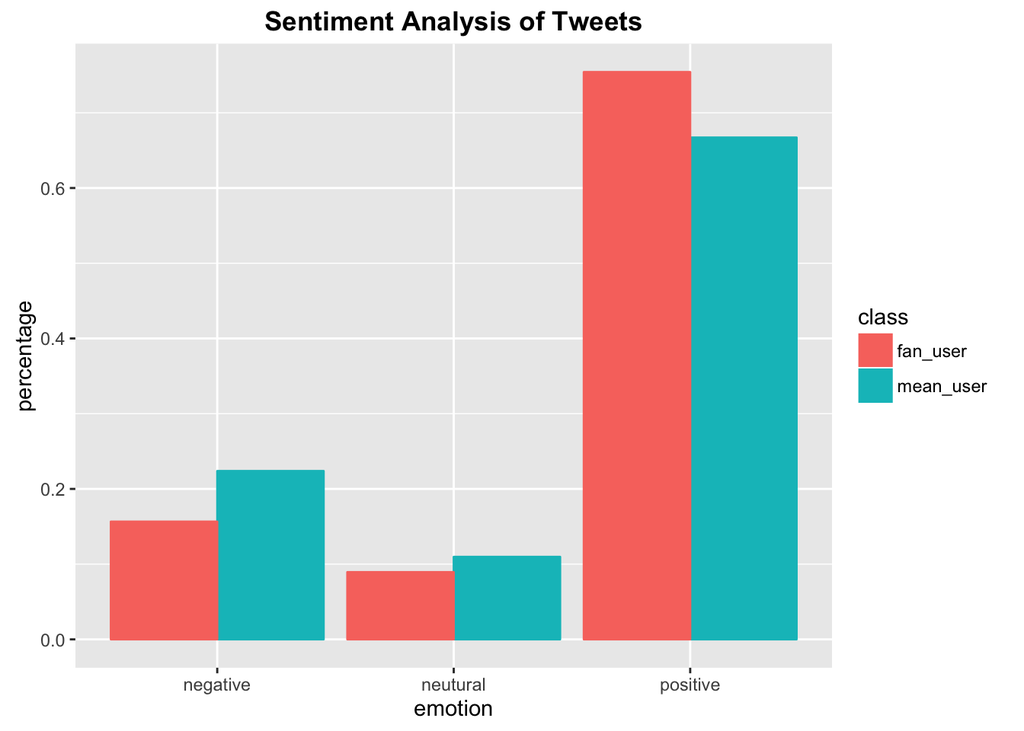

```r
#plot
ggplot(sentiment.tweet,aes(x=emotion,y=percentage,group=class,fill=class)) +
        geom_bar(aes(colour = class),stat="identity",position="dodge") +
        labs(title = "Sentiment Analysis of Tweets") +
        theme(plot.title = element_text(lineheight=.8, face="bold"))
```

```r
###individual level
#paste data
tweet.mean <- NULL
for (i in 1:n.mean){
        tweet.mean[i] <- paste(tweet.mean.list[[i]],sep = " ", collapse = ' ')
}
tweet.fan <- NULL
for (i in 1:n.fan){
        tweet.fan[i] <- paste(tweet.fan.list[[i]],sep = " ", collapse = ' ')
}
sentiment.mean.person <- classify_polarity(tweet.mean, algorithm="bayes")[,4]
sentiment.fan.person <- classify_polarity(tweet.fan, algorithm="bayes")[,4]
#data frame
sentiment.individual <- data.frame(emotion = as.factor(rep(c("negative","neutural","positive"),2)), percentage = c(length(which(sentiment.mean.person=="negative"))/n.mean,length(which(sentiment.mean.person=="neutral"))/n.mean,length(which(sentiment.mean.person=="positive"))/n.mean,length(which(sentiment.fan.person=="negative"))/n.fan,length(which(sentiment.fan.person=="neutral"))/n.fan,length(which(sentiment.fan.person=="positive"))/n.fan),class = as.factor(c(rep("mean_user",3),rep("fan_user",3))))
sentiment.individual
```

```
##    emotion percentage     class
## 1 negative  0.3965517 mean_user
## 2 neutural  0.4310345 mean_user
## 3 positive  0.1724138 mean_user
## 4 negative  0.1235294  fan_user
## 5 neutural  0.5000000  fan_user
## 6 positive  0.3764706  fan_user
```

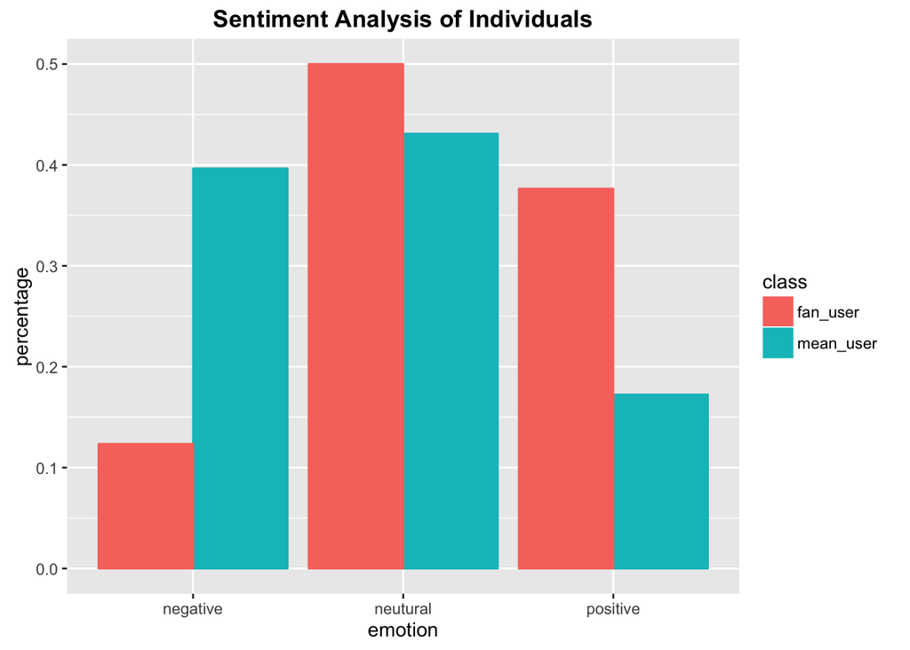

```r
#plot
ggplot(sentiment.individual,aes(x=emotion,y=percentage,group=class,fill=class)) +
        geom_bar(aes(colour = class),stat="identity",position="dodge") +
        labs(title = "Sentiment Analysis of Individuals") +
        theme(plot.title = element_text(lineheight=.8, face="bold"))
```

```r
###percentage distribution of indivudual
sentiment.mean.matrix <- matrix(nrow = n.mean,ncol = 3)
sentiment.fan.matrix <- matrix(nrow = n.fan,ncol = 3)
for (i in 1:n.mean){
        result <- classify_polarity(tweet.mean.list[[i]], algorithm="bayes")[,4]
        n <- length(tweet.mean.list[[i]])
        sentiment.mean.matrix[i,1] <- length(which(result=="positive"))/n
        sentiment.mean.matrix[i,2] <- length(which(result=="neutral"))/n
        sentiment.mean.matrix[i,3] <- length(which(result=="negative"))/n
}
for (i in 1:n.fan){
        result <- classify_polarity(tweet.fan.list[[i]], algorithm="bayes")[,4]
        n <- length(tweet.fan.list[[i]])
        sentiment.fan.matrix[i,1] <- length(which(result=="positive"))/n
        sentiment.fan.matrix[i,2] <- length(which(result=="neutral"))/n
        sentiment.fan.matrix[i,3] <- length(which(result=="negative"))/n
}
#data frame
percentage.dist <- data.frame(percentage = c(sentiment.mean.matrix[,1],sentiment.mean.matrix[,3],sentiment.fan.matrix[,1],sentiment.fan.matrix[,3]),class = c(rep("mean.positive",n.mean),rep("mean.negative",n.mean),rep("fan.positive",n.fan),rep("fan.negative",n.fan)))
head(percentage.dist)
```

```
##   percentage         class
## 1  0.4136126 mean.positive
## 2  0.6153846 mean.positive
## 3  0.6800000 mean.positive
## 4  0.7398374 mean.positive
## 5  0.3369565 mean.positive
## 6  0.4140127 mean.positive
```

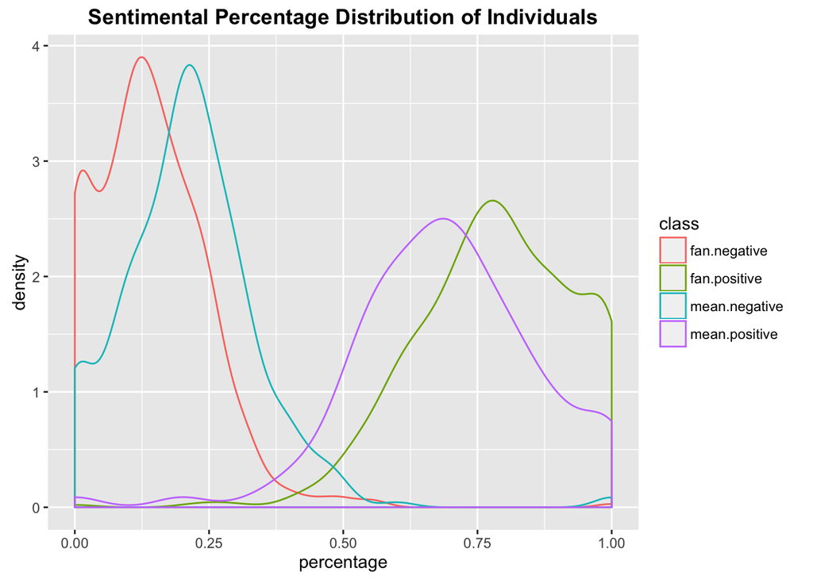

```r
#plot
ggplot(percentage.dist,aes(percentage,colour = class)) + geom_density() +
        labs(title = "Sentimental Percentage Distribution of Individuals") +
        theme(plot.title = element_text(lineheight=.8, face="bold"))
```

### 3 The model

## 3.1 Feature selection

Collapse all tweets for trolls as a single text and all tweets for fans as another single text. Compute the frenquency for each appearing word. If word A appears in one text but not the other, set the freqency of A in the other text as 0. Rank all words by descending order of the frenquency difference. Choose top 200 words as feature words.

We randomly choose 80% of the data as training data and 20% as testing data. We select feature and fit the model on the training set and evaluate the model performance on the test set.

```r
#training and testing set
tweet.mean <- NULL
for (i in 1:n.mean){
        tweet.mean[i] <- paste(tweet.mean.list[[i]],sep = " ", collapse = ' ')
}
tweet.fan <- NULL
for (i in 1:n.fan){
        tweet.fan[i] <- paste(tweet.fan.list[[i]],sep = " ", collapse = ' ')
}
tweet.mean <- gsub("[[:punct:]]","",tweet.mean)
tweet.mean <- tolower(tweet.mean)
tweet.fan <- gsub("[[:punct:]]","",tweet.fan)
tweet.fan <- tolower(tweet.fan)
#training set
set.seed(1)
id.mean <- sample(n.mean,n.mean*0.8)
id.fan <- sample(n.fan,n.fan*0.8)
tweet.mean.train <- tweet.mean[id.mean]
tweet.fan.train <- tweet.fan[id.fan]
text.mean <- paste(tweet.mean.train,sep = " ", collapse = ' ')
text.fan <- paste(tweet.fan.train,sep = " ", collapse = ' ')

text.mean.corpus <- Corpus(VectorSource(text.mean))
text.mean.corpus <- tm_map(text.mean.corpus,content_transformer(tolower))
text.mean.corpus <- tm_map(text.mean.corpus,removeWords,stopwords("en"))
matrix.mean <- TermDocumentMatrix(text.mean.corpus)
freq.word <- as.matrix(matrix.mean)
freq.word.order <- freq.word[order(freq.word,decreasing = TRUE),1]

text.fan.corpus <- Corpus(VectorSource(text.fan))
text.fan.corpus <- tm_map(text.fan.corpus,content_transformer(tolower))
text.fan.corpus <- tm_map(text.fan.corpus,removeWords,stopwords("en"))
matrix.fan <- TermDocumentMatrix(text.fan.corpus)
freq.word.fan <- as.matrix(matrix.fan)
freq.word.fan.order <- freq.word.fan[order(freq.word.fan,decreasing = TRUE),1]

#compute word frenquency
word.count.mean <- sum(freq.word.order)
freq.word.order <- freq.word.order/word.count.mean
freq.word.order <- data.frame(word = names(freq.word.order), freq = freq.word.order)
word.count.fan <- sum(freq.word.fan.order)
freq.word.fan.order <- freq.word.fan.order/word.count.fan
freq.word.fan.order <- data.frame(word = names(freq.word.fan.order),freq = freq.word.fan.order)
#compute frequency difference
word.all <- full_join(freq.word.order,freq.word.fan.order, by = "word")
head(word.all)
```

```
##            word      freq.x      freq.y
## 1          like 0.008154562 0.005968592
## 2 taylorswift13 0.007306243 0.016270683
## 3          just 0.007015828 0.006440061
## 4          dont 0.006457924 0.004283343
## 5           get 0.005143412 0.003495890
## 6          love 0.005135769 0.019631151
```

```r
word.all[is.na(word.all)] <- 0
word.compare <- word.all %>%
        mutate(diff = freq.x - freq.y, abs = abs(freq.x - freq.y)) %>%
        arrange(desc(abs)) %>%
        select(word,abs)
head(word.compare)
```

```
##             word         abs
## 1           love 0.014495382
## 2  taylorswift13 0.008964440
## 3         taylor 0.003977266
## 4 hillaryclinton 0.003315891
## 5       popcrave 0.002632604
## 6          happy 0.002413770
```

```r
dictionary_model <- word.compare[1:200,1]
```

## 3.2 Convert to vector input

For each person, construct a 200 dimensional vector, corresponding to the frequencies of the 200 selected feature words in this person’s tweets.

```r
#count the number of dictionary words for each person
train.mean <- sapply(dictionary_model, function(x) MyCount(tweet.mean,x))
train.fan <- sapply(dictionary_model, function(x) MyCount(tweet.fan,x))
#count the number of total words for each person
count.mean <- as.numeric(lapply(tweet.mean,function(x) length(strsplit(x,' ')[[1]])))
count.fan <-  as.numeric(lapply(tweet.fan,function(x) length(strsplit(x,' ')[[1]])))
#construct input data
train.mean <- train.mean/count.mean
train.fan <- train.fan/count.fan
y <- c(rep(1,n.mean),rep(0,n.fan))
data <- data.frame(y = y, rbind(train.mean,train.fan))
head(data)
```

```
##   y         love taylorswift13       taylor hillaryclinton popcrave
## 1 1 0.0155115512  0.0003300330 0.0003300330    0.000000000        0
## 2 1 0.0196078431  0.0098039216 0.0098039216    0.000000000        0
## 3 1 0.0008823529  0.0138235294 0.0147058824    0.040588235        0
## 4 1 0.0008826125  0.0044130627 0.0044130627    0.000000000        0
## 5 1 0.0009404389  0.0003134796 0.0003134796    0.019435737        0
## 6 1 0.0030529172  0.0003392130 0.0003392130    0.002035278        0
##         happy       please          day        like        dont
## 1 0.000660066 0.0006600660 0.0033003300 0.005610561 0.002640264
## 2 0.000000000 0.0000000000 0.0098039216 0.009803922 0.000000000
## 3 0.000000000 0.0000000000 0.0008823529 0.009411765 0.003235294
## 4 0.000000000 0.0008826125 0.0035304501 0.006178288 0.005295675
## 5 0.000000000 0.0003134796 0.0009404389 0.002507837 0.001253918
## 6 0.000000000 0.0003392130 0.0030529172 0.003052917 0.001696065
##         potus musicnewsfacts         much taylornation13        swift
```

[output cut: 237 more lines]

```r
id <- c(id.mean,n.mean+id.fan)
train <- data[id,]
test <- data[-id,]
```

## 3.3 Machine learning models

# 3.3.1 Logistic regression with L1 penalty

Fit a logistic regression with Lasso penalty on the training set. The optimal parameter is $\lambda = 0.02$. Words with non-zero coefficients are listed. The training accuracy is 0.853125 and the test accuracy is 0.725.

```r
library(glmnet)
#choose the best lambda
set.seed(1)
fit.glmnet <- cv.glmnet(x = as.matrix(train[,-1]),y = as.factor(train[,1]),family = "binomial")
```

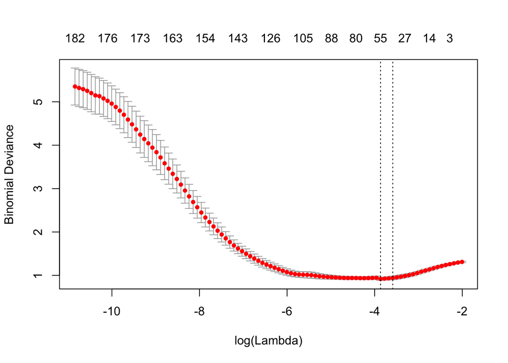

```r
plot(fit.glmnet)
```

```r
lambda <- fit.glmnet$lambda.min
lambda
```

```
## [1] 0.02095314
```

```r
coef(fit.glmnet,s=lambda)
```

```
## 201 x 1 sparse Matrix of class "dgCMatrix"
##                               1
## (Intercept)         -0.28648303
## love               -36.10595980
## taylorswift13        .
## taylor               .
## hillaryclinton      18.33594317
## popcrave             8.55095313
## happy                .
## please               .
## day                -32.58007380
## like                 0.75971015
## dont                 0.20752779
## potus                .
## musicnewsfacts       .
## much                 .
## taylornation13       .
## swift                .
## fuck                 5.54078318
## shit               104.61331376
## realdonaldtrump      .
## taylorswift          .
## get                  .
## quote                .
## great                .
## fbi                  .
## always               .
## bitch               90.16268864
## hope                -1.90225765
## fucking              .
## lt3                  .
## beautiful          -12.14474680
## bless                .
## got                  .
## nytimes              .
## good                 .
## see                 -9.96830921
## ako                  .
## miss               -19.52942838
## nydailynews          .
```

[output cut: 148 more lines]

```
## pay                  1.34110923
## candymag             .
## live                -2.31974492
## sunshinekissesv      .
## checked              .
## safe                 .
## doesnt               .
## person             -42.67928795
## guys                 .
## gay                  .
## talaga               .
## automatically        .
## slittlejenny         .
## goodwinaimanson      .
## tell                 .
```

```r
#arrange coef
coef <- as.matrix(coef(fit.glmnet,s=lambda))
coef<- data.frame(word = rownames(coef),coef = coef)
colnames(coef) <- c("word","coef")
coef <- coef %>% filter(coef!=0) %>% arrange(desc(coef))
coef.mean <- coef[1:35,]
coef.fan <- coef[56:37,]
rownames(coef.fan) = 1:20
#training error
y.train <- train[,"y"]
y.pred <- predict(fit.glmnet,newx = as.matrix(train[,-1]),s = lambda, type = "class")
table(y.pred,y.train)
```

```
##       y.train
## y.pred   0   1
##      0 392  78
##      1  16 154
```

```r
(table(y.pred,y.train)[1,1]+table(y.pred,y.train)[2,2])/sum(table(y.pred,y.train))
```

```
## [1] 0.853125
```

```r
#prediction error
glmnet.pred <- predict(fit.glmnet,newx = as.matrix(test[,-1]),s = lambda, type = "class")
y.test <- test[,"y"]
table(glmnet.pred,y.test)
```

```
##            y.test
## glmnet.pred  0  1
##           0 91 33
##           1 11 25
```

```r
(table(glmnet.pred,y.test)[1,1]+table(glmnet.pred,y.test)[2,2])/sum(table(glmnet.pred,y.test))
```

```
## [1] 0.725
```

# 3.3.2 Classification tree

Fit a classification tree on the training set. The fitted tree has 25 internal nodes(variables) and 28 terminal nodes. The accuracy is 0.90938 on the training set. The accuracy on the test set is 0.7125. Use 10 fold cross validation on the training set to select the best tree size. The best tree size is 14 with deviance 136. Then fit the tree with size 14 on the training set. The accuracy on the training set is 0.8828, while the accuracy on the test set is 0.725.

```r
library(tree)
#fit tree
set.seed(1)
fit.tree <- tree(as.factor(y)~.,data = train)
summary(fit.tree)
```

```
##
## Classification tree:
## tree(formula = as.factor(y) ~ ., data = train)
## Variables actually used in tree construction:
##  [1] "love"          "fuck"          "just"          "great"
##  [5] "music"         "bitch"         "now"           "days"
##  [9] "via"           "can"           "cute"          "take"
## [13] "que"           "follow"        "come"          "fan"
## [17] "taylorswift13" "black"         "world"         "shawnmendes"
## [21] "name"          "snake"         "new"           "heart"
## [25] "like"
## Number of terminal nodes:  28
## Residual mean deviance:  0.3876 = 237.2 / 612
## Misclassification error rate: 0.09062 = 58 / 640
```

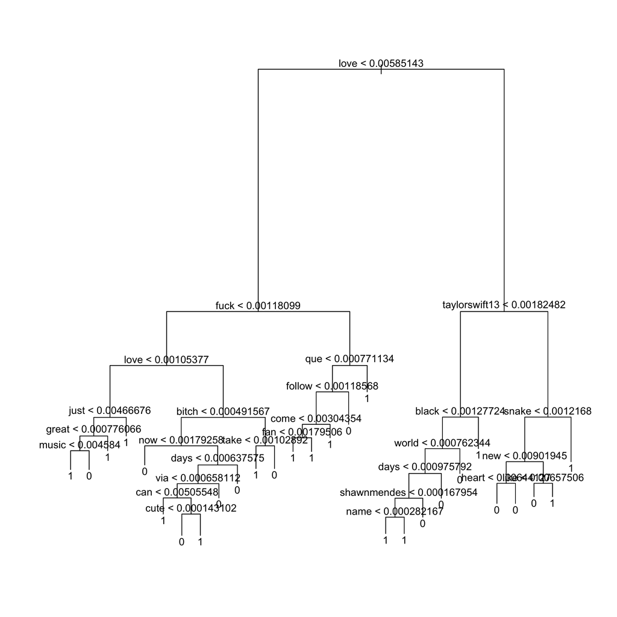

```r
plot(fit.tree)
text(fit.tree,pretty =0)
```

```r
#prediction error
tree.pred <- predict(fit.tree,test,type="class")
table(tree.pred,y.test)
```

```
##          y.test
## tree.pred  0  1
##         0 70 14
##         1 32 44
```

```r
(table(tree.pred,y.test)[1,1]+table(tree.pred,y.test)[2,2])/sum(table(tree.pred,y.test))
```

```
## [1] 0.7125
```

```r
#cv to choose best size
set.seed(1)
cv.tree.best =cv.tree(fit.tree,FUN=prune.misclass)
cv.tree.best
```

```
## $size
## [1] 28 22 19 14 11  5  4  2  1
##
## $dev
## [1] 149 148 136 136 144 149 156 168 223
##
## $k
## [1] -Inf  0.0  2.0  2.2  4.0  5.0  8.0 19.5 68.0
##
## $method
## [1] "misclass"
##
## attr(,"class")
## [1] "prune"         "tree.sequence"
```

```r
#fit tree for best size
prune.tree <- prune.misclass(fit.tree,best=14)
summary(prune.tree)
```

```
##
## Classification tree:
## snip.tree(tree = fit.tree, nodes = c(14L, 20L, 96L, 8L, 18L))
## Variables actually used in tree construction:
##  [1] "love"          "fuck"          "bitch"         "take"
##  [5] "que"           "follow"        "taylorswift13" "black"
##  [9] "world"         "days"          "shawnmendes"   "snake"
## Number of terminal nodes:  14
## Residual mean deviance:  0.6223 = 389.6 / 626
## Misclassification error rate: 0.1172 = 75 / 640
```

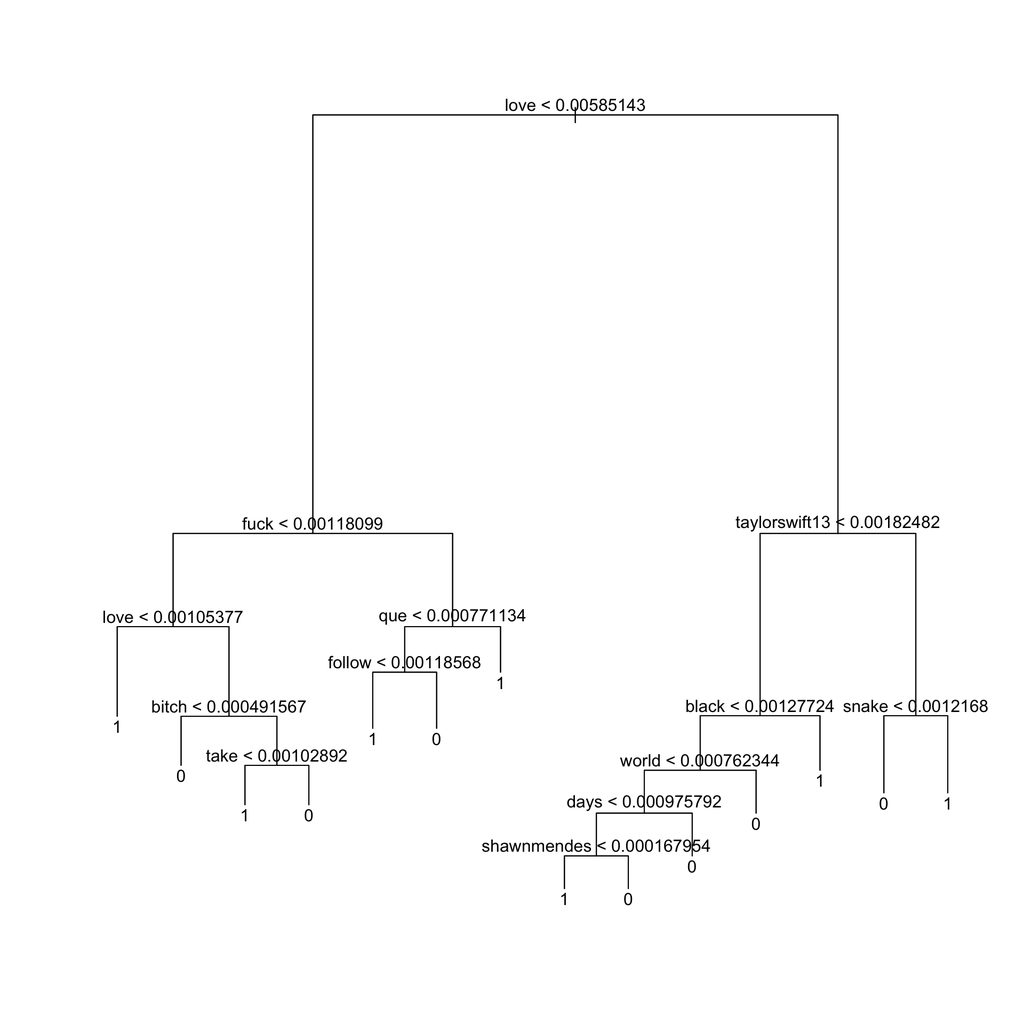

```r
plot(prune.tree)
text(prune.tree,pretty=0)
```

```r
#test error
tree.pred.prune <- predict(prune.tree,test,type="class")
table(tree.pred.prune,y.test)
```

```
##                y.test
## tree.pred.prune  0  1
##               0 72 14
##               1 30 44
```

```r
(table(tree.pred.prune,y.test)[1,1]+table(tree.pred.prune,y.test)[2,2])/sum(table(tree.pred.prune,y.test))
```

```
## [1] 0.725
```

# 3.3.3 Bagging and Random Forest

Bagging is a special case of random forest with m=p, namely to consider all predictors in each node. The accuracy on the trining set is 0.821875 and the accuracy on the test set is 0.80625.

Random forest considers m predictors in each node. Here we choose $m=\sqrt{p} = \sqrt{200} = 14$ predictors.Variable importance plot shows similar result as bagging. The accuracy on the training set is 0.834375 and the accuarcy on the test set is 0.83125.

```r
library(randomForest)
#bagging
set.seed(1)
fit.bag <- randomForest(as.factor(y)~.,data = train,mtry=200,importance =TRUE)
fit.bag
```

```
##
## Call:
##  randomForest(formula = as.factor(y) ~ ., data = train, mtry = 200,      importance = TRUE)
##                Type of random forest: classification
##                      Number of trees: 500
## No. of variables tried at each split: 200
##
##         OOB estimate of  error rate: 17.81%
## Confusion matrix:
##     0   1 class.error
## 0 349  59   0.1446078
## 1  55 177   0.2370690
```

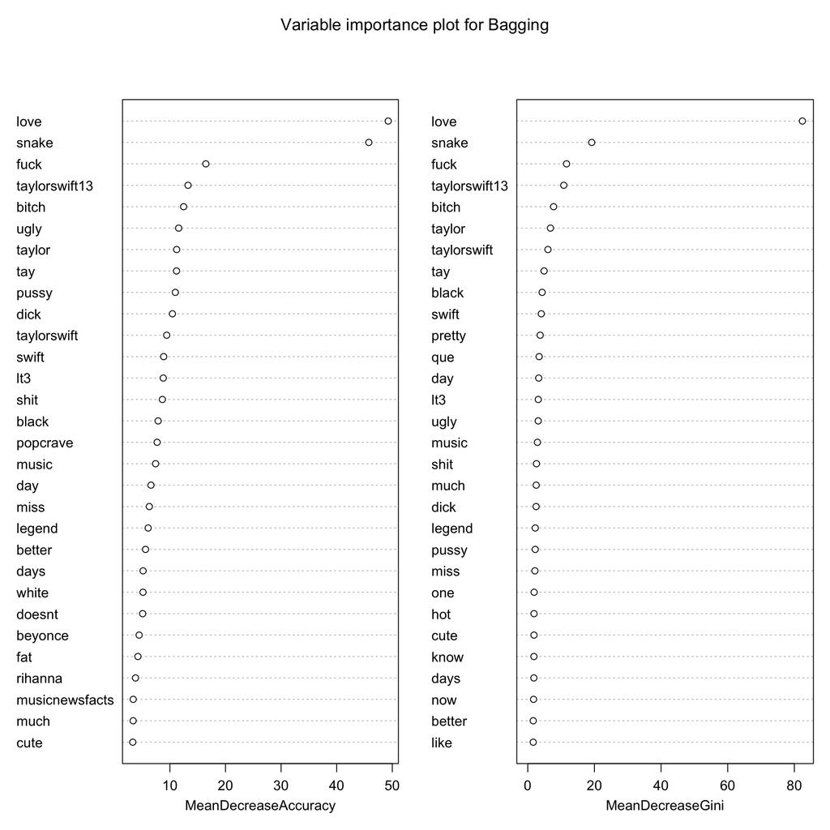

```r
varImpPlot(fit.bag,main = "Variable importance plot for Bagging")
```

```r
#training error
table <- fit.bag$confusion[,1:2]
(table[1,1]+table[2,2])/sum(table)
```

```
## [1] 0.821875
```

```r
#test error
bag.pred <- predict(fit.bag,newdata=test)
table(bag.pred,y.test)
```

```
##         y.test
## bag.pred  0  1
##        0 82 11
##        1 20 47
```

```r
(table(bag.pred,y.test)[1,1]+table(bag.pred,y.test)[2,2])/sum(table(bag.pred,y.test))
```

```
## [1] 0.80625
```

```r
#random forest
set.seed(1)
fit.forest <- randomForest(as.factor(y)~.,data = train,importance = TRUE)
fit.forest
```

```
##
## Call:
##  randomForest(formula = as.factor(y) ~ ., data = train, importance = TRUE)
##                Type of random forest: classification
##                      Number of trees: 500
## No. of variables tried at each split: 14
##
##         OOB estimate of  error rate: 16.56%
## Confusion matrix:
##     0   1 class.error
## 0 359  49   0.1200980
## 1  57 175   0.2456897
```

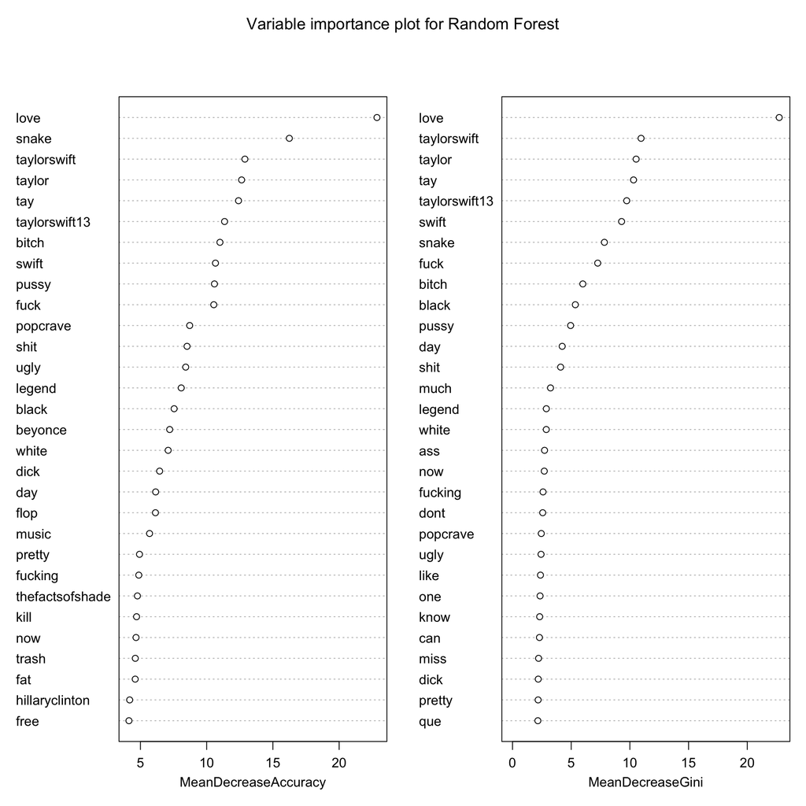

```r
varImpPlot(fit.forest,main = "Variable importance plot for Random Forest")
```

```r
#training error
table <- fit.forest$confusion[,1:2]
(table[1,1]+table[2,2])/sum(table)
```

```
## [1] 0.834375
```

```r
#test error
forest.pred <- predict(fit.forest,newdata=test)
table(forest.pred,y.test)
```

```
##            y.test
## forest.pred  0  1
##           0 87 12
##           1 15 46
```

```r
(table(forest.pred,y.test)[1,1]+table(forest.pred,y.test)[2,2])/sum(table(forest.pred,y.test))
```

```
## [1] 0.83125
```